# Dask and XGBoost on a Cluster

We use Dask and XGBoost together on a cluster to load, clean, train, and predict against biggish data. We perform the following steps:

1. Load, clean, and prepare CSV data with Dask.dataframe
2. Set up a distributed XGBoost network with Dask to run in the same processes running Dask workers.
3. Hand data from Dask to XGBoost directly in memory
4. Use XGBoost to train on data, getting back a normal XGBoost result
5. Use Dask and XGBoost together to test our model against held out data
6. Use SKLearn functions to measure the success of the trained model

This notebook relies on around 170 lines of code in github.com/mrocklin/dask-xgboost

```
pip install git+https://github.com/mrocklin/dask-xgboost
```

```python
from dask import compute, persist
from dask.distributed import Client, progress

client = Client('172.31.33.0:8786')
client.restart()
```

```
<Client: scheduler='tcp://172.31.33.0:8786' processes=10 cores=80>
```

## Load the Data

```python
import dask.dataframe as dd

# Subset of the columns to use
cols = ['Year', 'Month', 'DayOfWeek', 'Distance',
        'DepDelay', 'CRSDepTime', 'UniqueCarrier', 'Origin', 'Dest']

# Create the dataframe
df = dd.read_csv('s3://dask-data/airline-data/20*.csv', usecols=cols,
                  storage_options={'anon': True})

df = df.sample(frac=0.2) # XGBoost requires a bit of RAM, we need a larger cluster for this

is_delayed = (df.DepDelay.fillna(16) > 15)  # column of labels
del df['DepDelay']  # Remove delay information from training dataframe

df['CRSDepTime'] = df['CRSDepTime'].clip(upper=2399)

df, is_delayed = persist(df, is_delayed)  # Ask Dask to start work on these in the background
progress(df, is_delayed)
```

```python
df.head()
```

|  | Year | Month | DayOfWeek | CRSDepTime | UniqueCarrier | Origin | Dest | Distance |
| --- | --- | --- | --- | --- | --- | --- | --- | --- |
| 182193 | 2000 | 1 | 2 | 800 | WN | LAX | OAK | 337 |
| 83424 | 2000 | 1 | 6 | 1650 | DL | SJC | SLC | 585 |
| 346781 | 2000 | 1 | 5 | 1140 | AA | ORD | LAX | 1745 |
| 375935 | 2000 | 1 | 2 | 1940 | DL | PHL | ATL | 665 |
| 309373 | 2000 | 1 | 4 | 1028 | CO | MCI | IAH | 643 |

```python
is_delayed.head()
```

```
182193    False
83424     False
346781    False
375935    False
309373    False
Name: DepDelay, dtype: bool
```

## One hot encode

XGBoost doesn't want to work with text data like `destination="LAX"`. Instead we create new indicator columns for each of the known airports and carriers. This expands our data into many boolean columns. Fortunately Dask.dataframe has convenience functions for all of this baked in (thank you Pandas!)

```python
df2 = dd.get_dummies(df.categorize()).persist()
```

```python
len(df2.columns)
```

```
685
```

```python
df2.head()
```

|  | Year | Month | DayOfWeek | CRSDepTime | Distance | UniqueCarrier_WN | UniqueCarrier_DL | UniqueCarrier_AA | UniqueCarrier_CO | UniqueCarrier_UA | ... | Dest_RHI | Dest_INL | Dest_BJI | Dest_ROW | Dest_GCC | Dest_RKS | Dest_MKG | Dest_LMT | Dest_OTH | Dest_PIR |
| --- | --- | --- | --- | --- | --- | --- | --- | --- | --- | --- | --- | --- | --- | --- | --- | --- | --- | --- | --- | --- | --- |
| 182193 | 2000 | 1 | 2 | 800 | 337 | 1 | 0 | 0 | 0 | 0 | ... | 0 | 0 | 0 | 0 | 0 | 0 | 0 | 0 | 0 | 0 |
| 83424 | 2000 | 1 | 6 | 1650 | 585 | 0 | 1 | 0 | 0 | 0 | ... | 0 | 0 | 0 | 0 | 0 | 0 | 0 | 0 | 0 | 0 |
| 346781 | 2000 | 1 | 5 | 1140 | 1745 | 0 | 0 | 1 | 0 | 0 | ... | 0 | 0 | 0 | 0 | 0 | 0 | 0 | 0 | 0 | 0 |
| 375935 | 2000 | 1 | 2 | 1940 | 665 | 0 | 1 | 0 | 0 | 0 | ... | 0 | 0 | 0 | 0 | 0 | 0 | 0 | 0 | 0 | 0 |
| 309373 | 2000 | 1 | 4 | 1028 | 643 | 0 | 0 | 0 | 1 | 0 | ... | 0 | 0 | 0 | 0 | 0 | 0 | 0 | 0 | 0 | 0 |

5 rows × 685 columns

## Split and Train

We split our data randomly in a 90%/10% split for training and testing.

We pull parameters from [this similar experiment](https://github.com/szilard/benchm-ml/blob/master/3-boosting/6-xgboost.R#L28-L32).

We then set up XGBoost and hand data off for training

```python
data_train, data_test = df2.random_split([0.9, 0.1],
                                         random_state=1234)
labels_train, labels_test = is_delayed.random_split([0.9, 0.1],
                                                    random_state=1234)
```

```python
%%time
import dask_xgboost as dxgb

params = {'objective': 'binary:logistic', 'nround': 1000,
          'max_depth': 16, 'eta': 0.01, 'subsample': 0.5,
          'min_child_weight': 1,
          'tree_method': 'hist', 'grow_policy': 'lossguide' }  # these extra paramters recommended by @ogrisel

bst = dxgb.train(client, params, data_train, labels_train)
bst
```

```
CPU times: user 355 ms, sys: 29.7 ms, total: 385 ms
Wall time: 54.5 s
```

Our output is just a normal XGBoost Booster object.

```python
bst
```

```
<xgboost.core.Booster at 0x7fa1c18c4c18>
```

## Predict and Evaluate

We get back a normal XGBoost model. We can hand it normal Pandas data or use dask-xgboost again to predict against our hold-out testing data.

We numerically evaluate the result using ROC utilities from Scikit-learn

```python
# Use normal XGBoost model with normal Pandas
import xgboost as xgb
dtest = xgb.DMatrix(data_test.head())
bst.predict(dtest)
```

```
array([ 0.464578  ,  0.46631625,  0.47434333,  0.47245741,  0.46194169], dtype=float32)
```

```python
# Or use dask-xgboost to predict in parallel across the cluster
predictions = dxgb.predict(client, bst, data_test).persist()
predictions.head()
```

```
309373    0.464578
304274    0.466316
371593    0.474343
257351    0.472457
123003    0.461942
Name: predictions, dtype: float32
```

```python
predictions
```

```
Dask Series Structure:
npartitions=93
None    float32
None        ...
         ...
None        ...
None        ...
Name: predictions, dtype: float32
Dask Name: _predict_part, 93 tasks
```

### Evaluate

We use convenience functions from SKLearn to judge our results.

```python
from sklearn.metrics import roc_auc_score, roc_curve
print(roc_auc_score(labels_test.compute(),
                    predictions.compute()))
```

```
0.654800768411
```

```python
import matplotlib.pyplot as plt
%matplotlib inline
```

```python
fpr, tpr, _ = roc_curve(labels_test.compute(), predictions.compute())
```

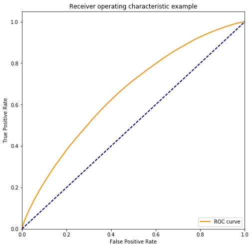

```
distributed.client - WARNING - Client report stream closed to scheduler
```

```python
# Taken from http://scikit-learn.org/stable/auto_examples/model_selection/plot_roc.html#sphx-glr-auto-examples-model-selection-plot-roc-py
plt.figure(figsize=(8, 8))
lw = 2
plt.plot(fpr, tpr, color='darkorange', lw=lw, label='ROC curve')
plt.plot([0, 1], [0, 1], color='navy', lw=lw, linestyle='--')
plt.xlim([0.0, 1.0])
plt.ylim([0.0, 1.05])
plt.xlabel('False Positive Rate')
plt.ylabel('True Positive Rate')
plt.title('Receiver operating characteristic example')
plt.legend(loc="lower right")
plt.show()
```